# DATA 605 Final Project

## Barplots & Catagorical Data

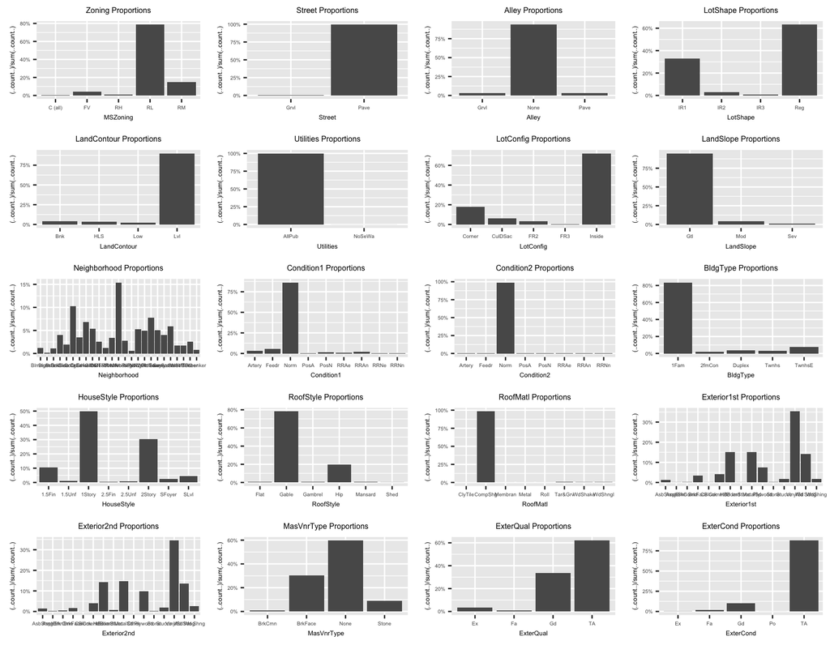

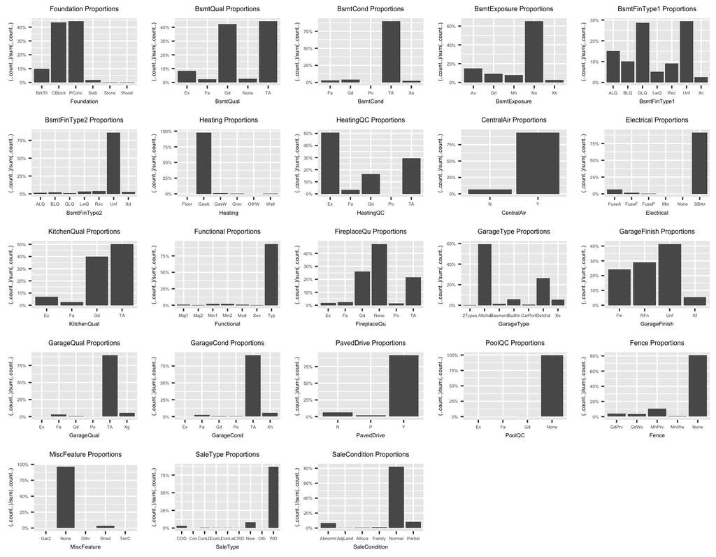

## Histograms for Ordinal Data

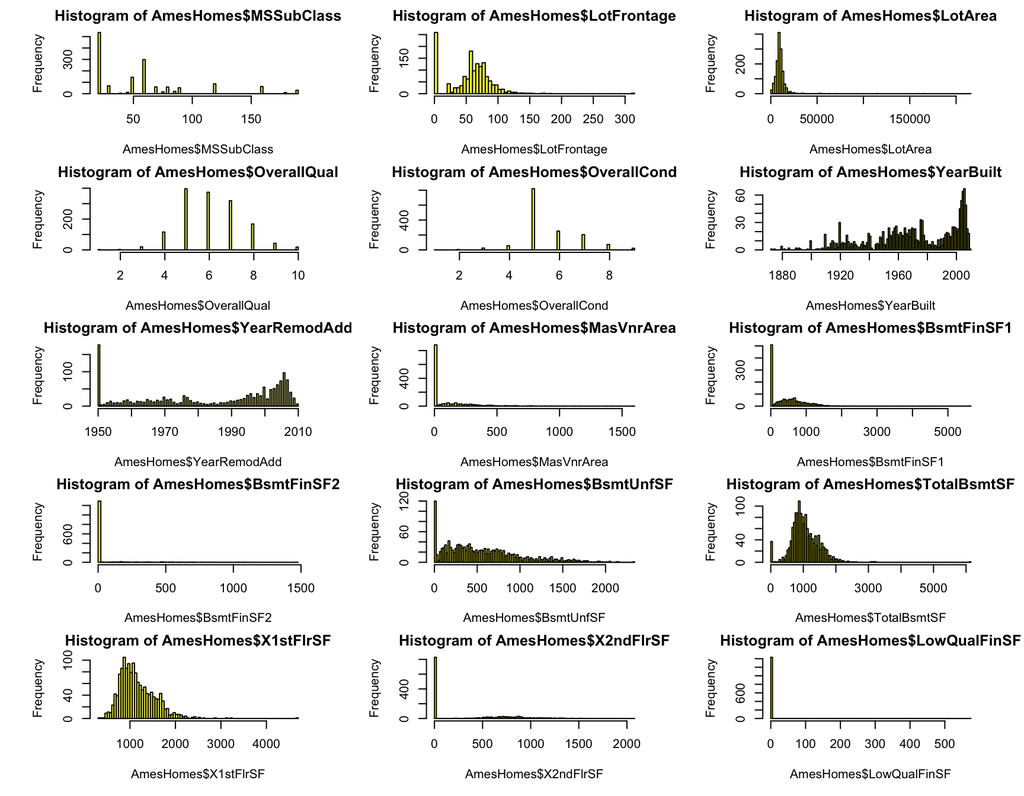

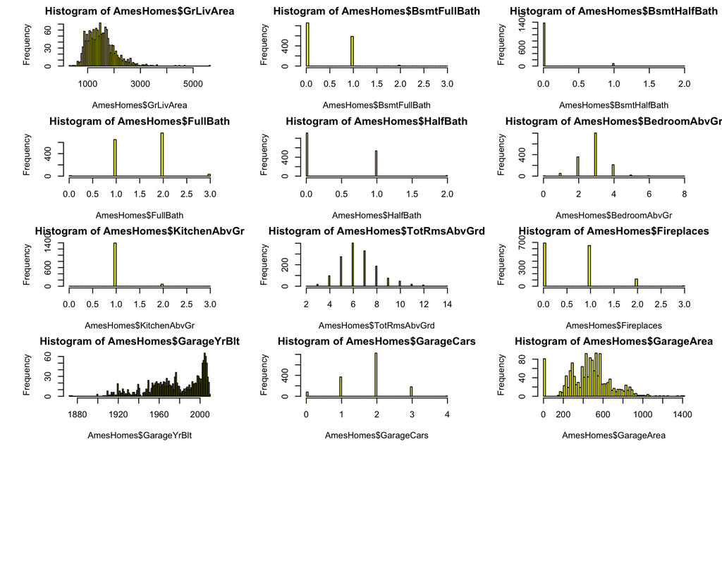

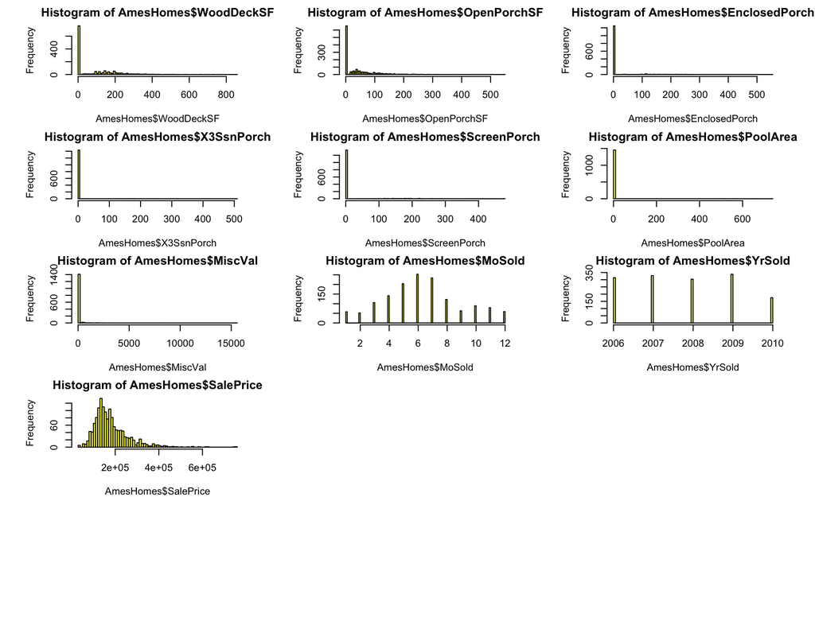

## Scatterplot

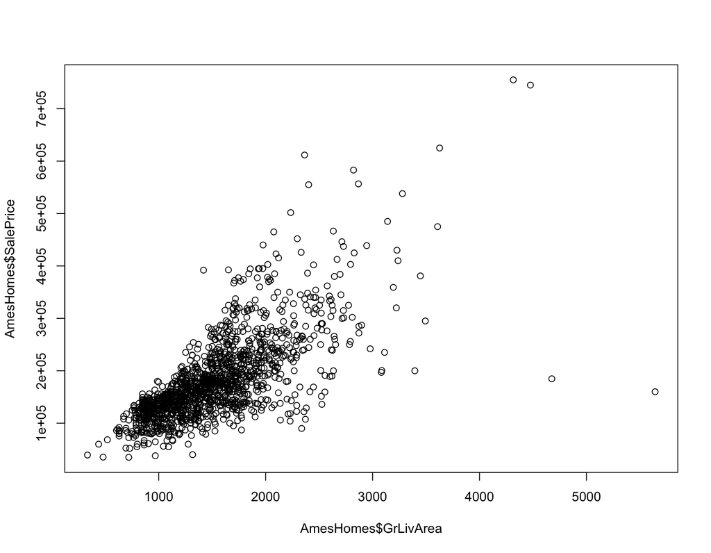

Provide a 95% CI for the difference in the mean of the variables.

Derive a correlation matrix for two of the quantitative variables you selected. Test the hypothesis that the correlation between these variables is 0 and provide a 99% confidence interval. Discuss the meaning of your analysis.

17. Provide a 95% CI for the difference in the mean of the variables.
- If 100 sample distibutions are taken from the population, 95 of them are likely to have prices within the confidence interval -183465.0 -175346.4

```r
t1 <- t.test( X, Y, paired = TRUE, conf.level = 0.95)
t1
```

```
##
##  Paired t-test
##
## data:  X and Y
## t = -86.695, df = 1459, p-value < 2.2e-16
## alternative hypothesis: true difference in means is not equal to 0
## 95 percent confidence interval:
##  -183465.0 -175346.4
## sample estimates:
## mean of the differences
##               -179405.7
```

17. Derive a correlation matrix for two of the quantitative variables you selected. Test the hypothesis that the correlation between these variables is 0 and provide a 99% confidence interval. Discuss the meaning of your analysis.
- If 100 sample distibutions are taken from the population, 99 of them are likely to have correlations within the confidence interval 0.6733974 0.7406408. The p-value is negligible, so reject the null hypothesis that there is no correlation

```r
#shows strong positive correlation
c <- cor(AmesHomes[,c("GrLivArea","SalePrice")])
c
```

```
##           GrLivArea SalePrice
## GrLivArea 1.0000000 0.7086245
## SalePrice 0.7086245 1.0000000
```

```r
cor.test(AmesHomes$GrLivArea, AmesHomes$SalePrice,conf.level=.99)
```

```
##
##  Pearson's product-moment correlation
##
## data:  AmesHomes$GrLivArea and AmesHomes$SalePrice
## t = 38.348, df = 1458, p-value < 2.2e-16
## alternative hypothesis: true correlation is not equal to 0
## 99 percent confidence interval:
##  0.6733974 0.7406408
## sample estimates:
##       cor
## 0.7086245
```

# Linear Algebra and Correlation

Invert your correlation matrix. (This is known as the precision matrix and contains variance inflation factors on the diagonal.)

17. Multiply the correlation matrix by the precision matrix, and then multiply the precision matrix by the correlation matrix.

```r
#invert the correlation for precision
p <- solve(c)
p
```

```
##           GrLivArea SalePrice
## GrLivArea  2.008632 -1.423366
## SalePrice -1.423366  2.008632
```

```r
#precision * correlation
p %*% c
```

```
##           GrLivArea SalePrice
## GrLivArea         1         0
## SalePrice         0         1
```

```r
#correlation * precision
c %*% p
```

```
##           GrLivArea SalePrice
## GrLivArea         1         0
## SalePrice         0         1
```

17. Conduct principle components analysis (research this!) and interpret. Discuss.
- Comp 1 explains most of the variability in the data by a factor of 0.8543122 : 0.1456878

```r
par(oma=c(3,3,0,0),mar=c(3,3,2,2),mfrow=c(2,2))
# Pricipal Components Analysis
# entering raw data and extracting PCs
# from the correlation matrix
mydata <- data.frame(X,Y)
fit <- princomp(mydata, cor=TRUE)
summary(fit) # print variance accounted for
```

```
## Importance of components:
##                           Comp.1    Comp.2
## Standard deviation     1.3071436 0.5397921
## Proportion of Variance 0.8543122 0.1456878
## Cumulative Proportion  0.8543122 1.0000000
```

```r
loadings(fit) # pc loadings
```

```
##
## Loadings:
##   Comp.1 Comp.2
## X  0.707 -0.707
## Y  0.707  0.707
##
##                Comp.1 Comp.2
## SS loadings       1.0    1.0
## Proportion Var    0.5    0.5
## Cumulative Var    0.5    1.0
```

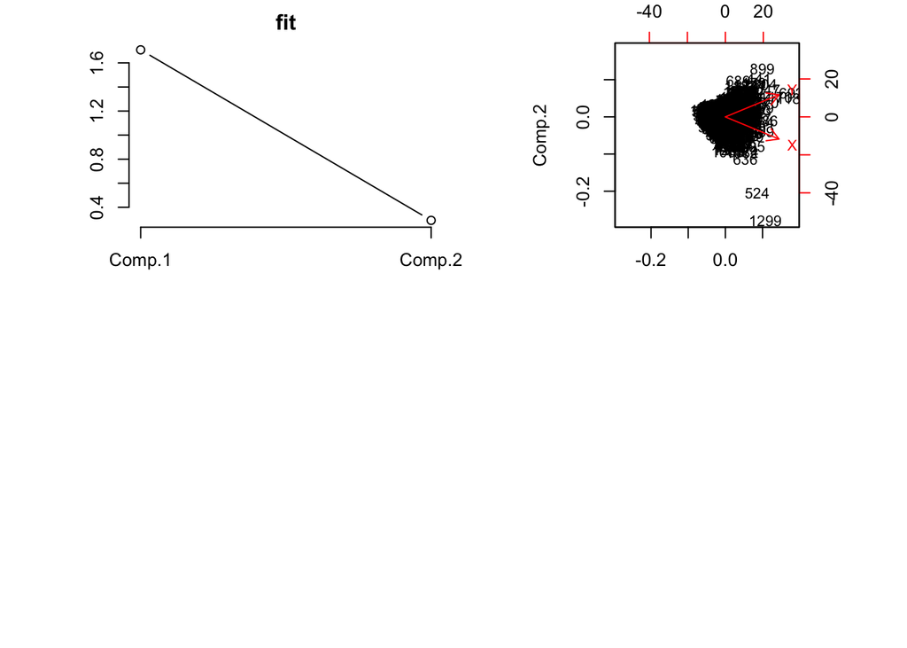

```r
plot(fit,type="lines") # scree plot
#fit$scores # the principal components
biplot(fit)
```